# Computational Statistics 6.2: Chi-square Test

## Chi-square test

### Overview

This lesson introduces the chi-square test.

### Objectives

After completing this module, you will be able to:

1. Test for independence between two variables.
2. Explain the derivation of the chi-square test.
3. Conduct a chi-squared test by hand and using R.

### Readings

Schumacker, Chapter 11.

## Relationships between multiple variables

So far we have examined a sequence of progressively more complex tests:

1. Is a sample mean equal to a fixed (null) value? (t-test for one sample)
2. Are two sample means equal to each other? (t-test for two samples)
3. Are three or more sample means all equal to each other? (ANOVA - F test)

Now we move on to examining the concept of *independence* between multiple variables. For example:

- Is unemployment status independent of educational attainment?
- Is the price of a luxury good independent of quality?
- Is life expectancy independent of carbon dioxide emissions?

## Independence

**Definition** : Two random variables $x$ and $y$ are **independently distributed**, or **independent**, if knowing the value of one of the variables provides no information about the other. Specifically, $X$ and $Y$ are independent if the conditional probability of $Y$ given $X$ is equal to the independent probability of $Y$. That is, $X$ and $Y$ are independently distributed if,

$$P(Y|X) = P(Y)$$

Now, using Bayes’ Theorem ($P(Y|X) = \dfrac{P(Y \& X)}{P(X)}$) in the previous expression yields;

$$\begin{eqnarray*}
P(Y|X) & = & P(Y) \\
\dfrac{P(Y \& X)}{P(X)} & = & P(Y) \\
P(Y \& X) & = & P(Y)P(X)
\end{eqnarray*}$$

That is, **the joint probability of two independent variables is the product of their independent probabilities**.

## Testing for independence

**Basic question:** Are two variables independent of each other?

**Hypotheses**

The hypotheses can be expressed as:

$H_0$: The variables $Y$ and $X$ are independent of each other.

$H_1$: The variables $Y$ and $X$ are not independent.

**Formally**

Using the definition of independence from the previous slide we can formalize this as:

$H_0$: $P(Y \& X) = P(Y)P(X)$

$H_1$: $P(Y \& X) \neq P(Y)P(X)$

**Example**

For example, are gender and political party ID independent of each other?

$H_0$: The variables `gender` and `party ID` are independent of each other.

$H_1$: The variables `gender` and `party ID` are not independent.

or

$H_0$: $P(\text{Gender} \& \text{Party ID}) = P(\text{Gender})P(\text{Party ID})$

$H_1$: $P(\text{Gender} \& \text{Party ID}) \neq P(\text{Gender})P(\text{Party ID})$

### Politics example

**Are gender and political affiliation dependent?** To answer this question first let’s examine a **frequency table** for gender and political affiliation.

**Data**:

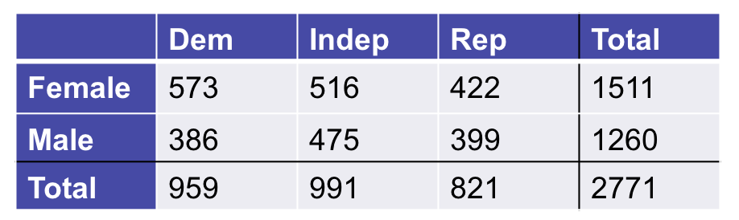

**Risk of jumping to erroneous conclusions:**

- If we observe a similar number males and females in a particular party we may conclude thatthere is no relationship between gender and politics.
- **What if there are more Democrats than Republicans in the database?** If there are more Democrats than Republicans, we would expect to see a similar numbers of male and female Demorats but more of each than male or female Republicans.
- **What if there are more females than males in our database?** Then we would expect to see more female Democrats than male Democrats, and the same for Republicans, but also more female Democrats than female Republicans, and the same for males.

### Examining independence I

Let’s say we have the following **data summary statistics:**

- 60% women and 40% men;
- and 70% Democrats vs 30% Republicans.

**If gender and political affiliation are independent:**

Let’s use the concept of independence to infer what is the expected percentage of each variable pair (`gender` and `party ID`) under the assumption of independence.

$\text{Expected joint probability} = P(\text{Gender} \& \text{Party ID}) = P(\text{Gender})P(\text{Party ID})$$

Then we would expect to see,

- $P(\text{Female}) \times P(\text{Democrat}) = 0.60 \times 0.70$ = `42` percent female Democrats,
- $P(\text{Female}) \times P(\text{Republican}) = 0.60 \times 0.30$ = `18` percent female Republicans
- $P(\text{Male}) \times P(\text{Democrat}) = 0.40 \times 0.70$ = `28` percent male Democrats, and,
- $P(\text{Male}) \times P(\text{Republican}) = 0.40 \times 0.30$ = `12` percent male Republicans.

In table format,

| Gender\Party ID | Democrat | Republican |
| --- | --- | --- |
| Female | 42% | 18% |
| Male | 28% | 12% |

**If gender and political affiliation are not independent,**

- then we would see statistically different percentages than the expected in the table above.

### Examining independence II-a

**Back to our politics datatable:**

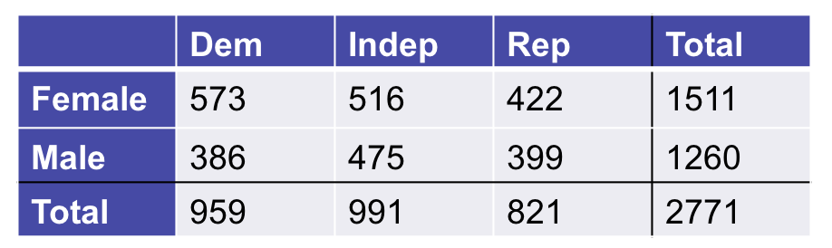

This are the actual percentages,

Percent female: 1511 / 2771 = 0.545

Percent male: 1260 / 2771 = 0.455

Percent Dem: 959 / 2771 = 0.346

Percent Indep: 991 / 2771 = 0.358

Percent Rep: 821 / 2771 = 0.296

### Examining independence II-b

**If gender and party ID are independent:**

If being Democrat and being female are independent of each other, then

$$p(Dem \& F) = p(Dem) * p(F) = 0.346*0.545 = 0.189$$

Thus the total number of female Democrats we would expect to see (the total in that cell) would be $0.189*2771 = 522.9$

We can do the exact same calculation for each cell, and the expected totals we get are:

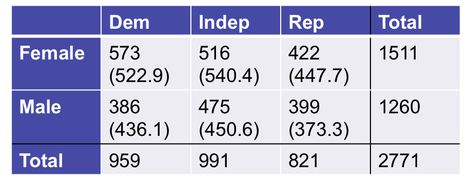

**But how different is enough to show it’s not just random?**

## Formalizing the test

Similar as the t test or the F test:

- We need a **test statistic** that summarizes how far off our counts in each cell are from what we would expect if the two variables are independent.
- When we have our test statistic, we can determine how unlikely it would be to get a number of that size.

### Calculating a test statistic

Our test statistic, called the *chi-squared* (or sometimes *chi-square*) statistic, is:

$$\chi^{2}= \sum \frac{(f_{o}-f_{e})^{2}}{f_{e}}$$

Where $f_{o} =$ observed number in a cell and $f_{e} =$ expected number in a cell, and the summation is over all the cells.

In words:

1. For each cell, we take the differences between the observed count and the expected count.
2. We square that difference,
3. and take it as fraction of the expected total;
4. and then we just add them all up.

So in this case, our statistic is:

$\chi^{2}= \sum \frac{(f_{o}-f_{e})^{2}}{f_{e}} = \frac{(573-522.9)^{2}}{522.9} + \frac{(516-540.4)^{2}}{540.4} + ... + \frac{(399 - 373.3)^{2} }{373.3} = 16.2$

Is this big enough?

### The chi-squared distribution

- The chi-square is just another distribution.
- Whereas the normal and T distributions, for instance, deal with sample statistics such as means, the chi-squared distribution characterizes the sum of *squared* normal statistics.
- Looking back at how we calculated our chi-square statistic, there are squared terms in the numerator, and of course the denominator is also positive (being a count), so the chi-square is always positive, and thus can’t be normal.

*Look at what happens if we square a bunch of normal samples and add them up. We get a distribution that looks like the $\chi^{2}$:*

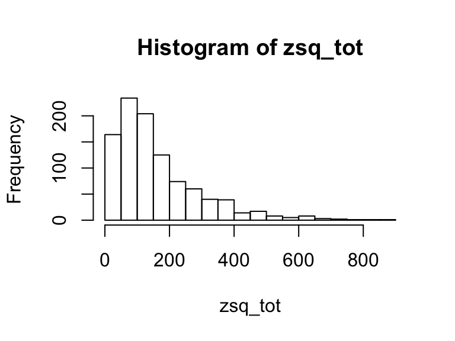

```r
z1 <- rnorm(1000,2,5)
z2 <- rnorm(1000,5,3)
z3 <- rnorm(1000,7,7)
zsq_tot <- z1^2 + z2^2 + z3^2
hist(zsq_tot,breaks=30)
```

### Degrees of freedom

- As usual, the chi-square distribution also has a shape parameter that is determined by the degrees of freedom.
- The degrees of freedom is not proportional to the number of samples (as with the t distribution) but to the number of cells in the table.

**Degrees of freedom:**

$$df = (r-1)(c-1)$$
,

where $r =$ number of rows, $c =$ number of columns.__

The various shapes of the $\chi^{2}$ depending on what the df are:

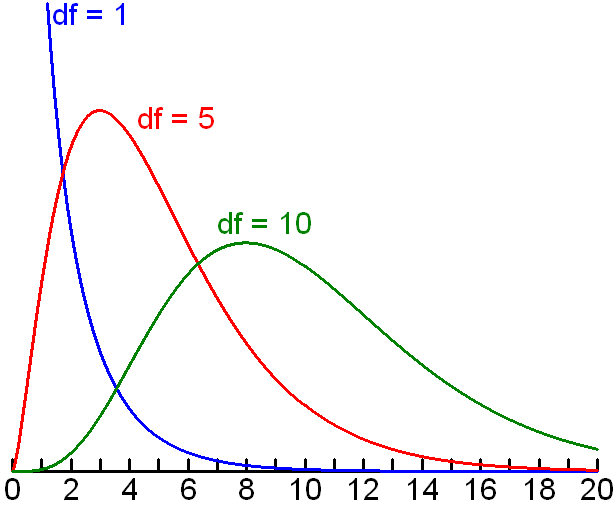

### Critical threshold value

- Our test statistic is a draw from the $\chi^{2}$ distribution (with the appropriate degrees of freedom), and the farther out it is, the less likely it is.
- The chi-square test is fundamentally one-tailed: we are only interested in whether the statistics is larger than we would expect if the variables were independent, and it can’t be negative due to squaring the differences.
- If it falls into the rejection region – eg, the region of the right tail of the distribution that accounts for less than 0.05 of the total, then we know that that number was unlikely to be that large just by chance alone.

To return to our example, the df is $(r-1)(c-1) = (2-1)(3-1) = 2$, and our test statistic was 16.2.

Our 95% threshold value is thus

```r
qchisq(.95, df=2)
```

```
[1] 5.991465
```

Our test statistic is clearly much larger (16.2 > 5.99), so we reject the null that these two variables (gender and political affiliation) are independent.

### Calculate p-value

We could similarly calculate the p-value directly and likewise reject the null:

```r
1-pchisq(16.2, df=2)
```

```
[1] 0.0003035391
```

### Using the table

Although again with modern computation, we don’t really need to use tables any more, we could also determine the test threshold value using the $\chi^{2}$ table:

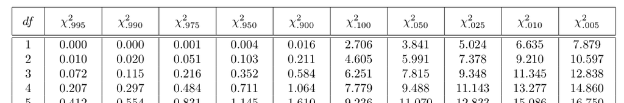

## Returning to our hypotheses

- Our conclusion: Gender and party are not independent.
- Can we say anything more?

$$\frac{(f_{o}-f_{e})^{2}}{f_{e}}$$

but now we consider both negative and positive values for differences $f_{o}-f_{e}$.

**Our datatable:**

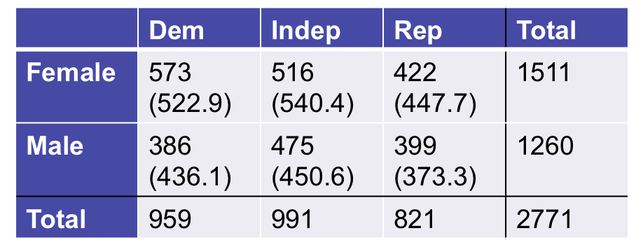

**Which cells are *over* or *under* their expected values?**

## Summary of procedure

1. $H_{0} =$ variables are independent.  
   $H_{a} =$ variables not independent.
2. Calculate $f_{e}$ for each cell.  
   Shortcut: $f_{e} = \frac{\textrm{(row total)(column total)}}{\textrm{overall total}}$
3. Calculate $\chi^{2} = \sum \frac{(f_{o}-f_{e})^{2}}{f_{e}}$
4. Calculate $df = (r-1)(c-1)$
5. Calculate the threshold value and reject the null if the test statistic (3) is greater than it.  
   Or calculate the p-value directly and reject the null if it is less than your chosen $\alpha$.

## Doing the chi-square test in R

```r
sexparty <- data.frame(dem=c(573,386),indep=c(516,475),rep=c(422,399),row.names=c("female","male"))
sexparty
```

```
       dem indep rep
female 573   516 422
male   386   475 399
```

```r
chisq.test(sexparty)
```

```
    Pearson's Chi-squared test

data:  sexparty
X-squared = 16.202, df = 2, p-value = 0.0003033
```

## Doing the chi-square test with GSS data in R

Calculating in R with the GSS data:

From http://gss.norc.org/About-The-GSS: “For more than four decades, the General Social Survey (GSS) has studied the growing complexity of American society. It is the only full-probability, personal-interview survey designed to monitor changes in both social characteristics and attitudes currently being conducted in the United States”. You can download this dataset from *Course Resources > Datasets* in Blackboard.

For this example, we want to know if the attitude towards the future is independent of the numbers of hours spent on the internet.

**First**, let’s load the GSS database

```r
setwd("/Users/econphd/Dropbox-NEU/Dropbox/Teaching/NEU/2019/PPUA5301/PPUA5301 - Summer 2019/Lectures/GSS")
gss <- readRDS("GSS2016.Rds")
```

**Second**, for this test are going to extract two variables from the database: (1) `LOTR3` which contains the answers to the survey question *“I’m always optimistic about my future”*, and, (2) `INTWKDYH` which contains the answers to the survey question *“How many minutes or hours do you spend actively using the Internet or web-enabled applications/APPS on a typical weekday?”*. The answers are in a scale of 1-7, any value outside of that range can be considered `NA` in the analysis.

```r
hope <- gss$LOTR3
internetUsage <- gss$intwkdyh
```

**Third**, Cleaning the data

```r
hope <- replace(hope, hope < 1 | hope > 7, NA)
internetUsage <- replace(internetUsage, internetUsage < 1  | internetUsage > 7, NA)

# Converting hope to numeric and internetUsage to factor
hope <- as.numeric(hope)
internetUsage <- as.factor(internetUsage)
```

**Fourth**, Join the two vectors in a data frame and make frequency table

```r
data.ex2 <- data.frame(hope, internetUsage)
tabularData <- table(data.ex2$hope, data.ex2$internetUsage)
data.ex2 <- as.data.frame.matrix(tabularData)
colnames <- paste("internet_group", 1:ncol(tabularData), sep = "_")
rownames <- paste("hope_group", 1:nrow(tabularData), sep = "_")
chisq.test(data.ex2)
```

```
    Pearson's Chi-squared test

data:  data.ex2
X-squared = 17.556, df = 24, p-value = 0.824
```

Then, at $\alpha = 0.05$, we **cannot** reject the null hypothesis that the average attitude towards the future and internet usage are independent variables.